# Exploring Participation in Events Based on Sociodemographic Characteristics

Nicolás Rubio García

November, 2023

## Introduction

In this project, a section of my undergraduate thesis is adapted, where I conduct a comprehensive analysis of the citizen participation model in activities in the departments of Caldas, Cundinamarca, and Boyacá. Various demographic, socioeconomic, and geographic factors influencing participation are evaluated, with Caldas established as the reference category due to its higher level of participation.

## The multinomial logit model

The chosen model for this task is the multinomial logit model. It is characterized by having a dependent variable that takes a number of finite and unordered discrete values, meaning it studies the probability of one event happening given another event.

As an example, if a dependent or endogenous variable has three categories and $P_1, P_2, P_3 \in [0, 1]$ are the probabilities of choosing or falling into any of these categories, then:

$$P_1 = \frac{1}{1 + \exp(x_i \beta_2) +
\exp(x_i \beta_3)}$$
$$P_2 =
\frac{\exp(x_i \beta_2)}{1 + \exp(x_i \beta_2) + \exp(x_i \beta_3)}$$
$$P_3 = \frac{\exp(x_i \beta_3)}{1
+ \exp(x_i \beta_2) + \exp(x_i \beta_3)}$$

Here, $x_i$ represents the values of the independent variables for the $ith$ observation, and $\beta_2$ and $\beta_3$ are the coefficients associated with the respective independent variables. The probabilities indicate the likelihood of an observation falling into each category given the values of the independent variables.

Where the decision for any of these alternatives depends on the characteristics $x_i$, and the log-odds ratios are:

$$\ln\left(\frac{P_2}{P_1}\right) = x_i
\beta_2 = \alpha_1^2 + \alpha_2^2 x_1 + \alpha_3^2 x_2$$

$$\ln\left(\frac{P_3}{P_1}\right) = x_i
\beta_3 = \alpha_1^3 + \alpha_2^3 x_1 + \alpha_3^3 x_2$$

$$\ln\left(\frac{P_2}{P_3}\right) = x_i
(\beta_2 - \beta_3) = (\alpha_1^2 - \alpha_1^3) + (\alpha_2^2 -
\alpha_2^3)x_1$$

Here, $x_i$ represents the values of the independent variables for the ith observation, and $\alpha_1^2$, $\alpha_2^2$, $\alpha_3^2$, $\alpha_1^3$, $\alpha_2^3$, $\alpha_3^3$ are the coefficients associated with the respective terms. The log-odds ratios express the logarithm of the likelihood of one category over another, given the values of the independent variables.

## Exploring data

The initial step involves analyzing the data to identify the presence of missing values and assess the overall data completeness:

```
##           Año         Fecha     ID Evento        Evento            ID
##          0.00          0.00          0.00          0.22          0.00
##    ID Usuario        Genero          Edad         Grupo          Zona
##          0.00          0.00          3.18          3.18          0.00
##   Escolaridad        vereda     Municipio Corregimiento  Departamento
##          0.00         75.30          0.00          0.00          0.00
##          dpto
##          0.00
```

As it could be seen, most variables are complete, and thus the model can be trained.

## Training the model

```
## Call:
## multinom(formula = dpto ~ Genero + Zona, data = df_parti_2023)
##
## Coefficients:
##              (Intercept) GeneroMujer ZonaUrbana
## Cundinamarca    -2.05224  -0.1477289  1.1800144
## Boyacá          -2.71679  -0.6915533  0.5891745
##
## Std. Errors:
##              (Intercept) GeneroMujer ZonaUrbana
## Cundinamarca  0.07939032  0.06928004 0.07843447
## Boyacá        0.12020715  0.12308235 0.12980380
##
## Residual Deviance: 7596.152
## AIC: 7608.152
```

```
##
## ==============================================
##                       Dependent variable:
##                   ----------------------------
##                    Cundinamarca      Boyacá
##                         (1)           (2)
## ----------------------------------------------
## GeneroMujer          -0.148**      -0.692***
##                       (0.069)       (0.123)
##
## ZonaUrbana           1.180***       0.589***
##                       (0.078)       (0.130)
##
## Constant             -2.052***     -2.717***
##                       (0.079)       (0.120)
##
## ----------------------------------------------
## Akaike Inf. Crit.    7,608.152     7,608.152
## ==============================================
## Note:              *p<0.1; **p<0.05; ***p<0.01
```

A notable aspect is the negative intercept, indicative of a general decrease in participation compared to Caldas. This finding is noteworthy, especially considering the increase in participants in the first two mentioned departments, while a decrease is observed in Caldas.

## Assumption tests

This model makes a specific assumption about the independence of irrelevant alternatives (IIA), where each possible alternative is differentiated and valued independently. In other words, the probability ratio between two alternatives does not depend on others. To test this assumption, the Hausman–McFadden test is commonly employed, with the null hypothesis $H_0$ being that the IIA holds in the model. Additionally, the Hosmer-Lemeshow goodness-of-fit test is conducted, where the null hypothesis $H_0$ is: There are no significant discrepancies between the observed frequencies and those predicted by the model.

```
##
##  Hausman-McFadden test
##
## data:  parti_2023
## chisq = -6.4618, df = 3, p-value = 1
## alternative hypothesis: IIA is rejected
```

```
##
##  Hosmer and Lemeshow test (multinomial model)
##
## data:  df_parti_2023$dpto, fitted(mlogit2023)
## X-squared = 0.91796, df = 2, p-value = 0.6319
```

In both tests, there is insufficient evidence to reject the null hypothesis $H_0$. Therefore, it can be asserted that the IIA assumption holds, and the model demonstrates a good prediction rate.

## Marginal effects

In order to interpret the probability results in linear terms, marginal effects are employed. These effects represent the impact of a change in the variable on the probability of falling into one of the alternatives. In other words, they are linearized parameters where the interpretation is not in comparison with a baseline alternative but rather on the probability of being in a specific category.

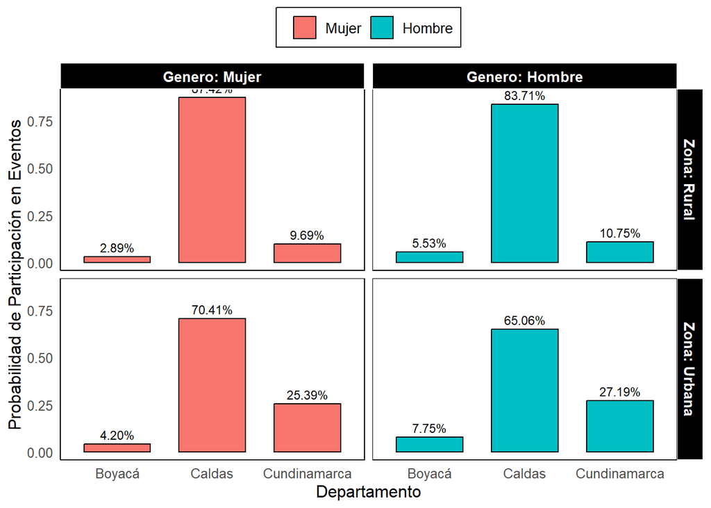

It is crucial to highlight that Caldas stands out as the department with the highest participation rate, as mentioned earlier, serving as a fundamental reference for comparison with Cundinamarca and Boyacá.